### Practical Machine Learning - Project Report

*Date: 22 October 2015*

#### Project Introduction

Devices such as *Jawbone Up*, *Nike Fuelband*, and *Fitbit* are getting increasingly popular due to its ability to track personal activities at a relatively inexpensive price. Users generally use such devices to quantify how *much* of a particular acitvity they do, but they rarely quantity **how well** they do it. As such, the goal of this project is to predict the manner in which they did the exercise.

For the purpose of this project, we will be using data from this source: http://groupware.les.inf.puc-rio.br/har. The data source consists of data from accelerometers on the belt, forearm, arm, and dumbbell of 6 participants. The participants were asked to perform barbell lifts correctly and incorrectly in 5 different ways:

1. Class A: Exactly according to specifications (the correct manner of lifting the dumbbell)
2. Class B: Throwing the elbows to the front
3. Class C: Lifting the dumbbell only halfway
4. Class D: Lowering the dumbbell only halfway
5. Class E: Throwing the hips to the front

Each participant was asked to perform a set of 10 repetitions.

#### Downloading and Reading the Data

```r
trainingdatadownload <- "https://d396qusza40orc.cloudfront.net/predmachlearn/pml-training.csv"
testdatadownload <- "https://d396qusza40orc.cloudfront.net/predmachlearn/pml-testing.csv"
trainingdata <- "./training.csv"
testdata <- "./test.csv"
if (!file.exists(trainingdata)) {
    download.file(trainingdatadownload,destfile=trainingdata,method="curl")
} ## Checks if training data file already exists in working directory
if (!file.exists(testdata)) {
    download.file(testdatadownload,destfile=testdata,method="curl")
} ## Checks if test data file already exists in working directory
```

```r
trainingset <- read.csv("./training.csv")
testset <- read.csv("./test.csv")
```

Let’s take a look at the datasets.

```r
dim(trainingset)
```

```
## [1] 19622   160
```

```r
summary(trainingset$classe)
```

```
##    A    B    C    D    E
## 5580 3797 3422 3216 3607
```

```r
dim(testset)
```

```
## [1]  20 160
```

As we can see, the training data set contains 19,622 observations and 160 variables, of which we are most concerned of the `classe` variable. The `classe` variable will be the outcome that we want to predict.

#### Cleaning the Data

We start cleaning both of the data sets by removing variables that contain *NA* values.

```r
trainingnoNA <- trainingset[,colSums(is.na(trainingset))==0]
testnoNA <- testset[,colSums(is.na(testset))==0]
```

Next, we remove columns that do not contribute significantly to the accelerometer measurements, i.e., variables that are not concerned with belt, forearm, arm, or dumbbell.

```r
classevariable <- trainingnoNA$classe ## We first create a classe object based on the values extracted from the training data set so that we can add it back to the tidied dataset later.
training.removevariables <- grepl("^X|timestamp|window",names(trainingnoNA)) ## Get the column numbers of the variables which we want to remove
trainingremoved <- trainingnoNA[,!training.removevariables]
trainingtidied <- trainingremoved[,sapply(trainingremoved,is.numeric)]
trainingtidied$classe <- classevariable ## Add in the classe variable
test.removevariables <- grepl("^X|timestamp|window",names(testnoNA)) ## Do the same thing for the test set
testremoved <- testnoNA[,!test.removevariables]
testtidied <- testremoved[,sapply(testremoved,is.numeric)]
```

Now, let’s take a look again at the tidied datasets.

```r
dim(trainingtidied)
```

```
## [1] 19622    53
```

```r
summary(trainingtidied$classe)
```

```
##    A    B    C    D    E
## 5580 3797 3422 3216 3607
```

```r
dim(testtidied)
```

```
## [1] 20 53
```

The training data set now contains 19,622 observations and 53 variables, and the `classe` variable remains.

#### Modeling the Data

To begin our prediction, we would first need to slice our training set into 70% (pure training data set) and 30% (validation data set), which the 30% validation data set will be used for cross-validation in the later part of our analysis.

```r
set.seed(8090) ## Set the seed to ensure reproducibility
inTrain <- createDataPartition(trainingtidied$classe,p=0.70,list=F)
trainData <- trainingtidied[inTrain,]
testData <- trainingtidied[-inTrain,]
```

We will then fit a predictive model for activity recognition. We will be using **Random Forest** algorithm here because it selects important variables and is able to correct for decision trees’ habit of overfitting to their training set. **5-fold cross validation** is used to apply the algorithm.

```r
control <- trainControl(method="cv",5)
model <- train(classe~.,data=trainData,method="rf",trControl=control,ntree=250)
model
```

```
## Random Forest
##
## 13737 samples
##    52 predictor
##     5 classes: 'A', 'B', 'C', 'D', 'E'
##
## No pre-processing
## Resampling: Cross-Validated (5 fold)
## Summary of sample sizes: 10990, 10991, 10989, 10990, 10988
## Resampling results across tuning parameters:
##
##   mtry  Accuracy   Kappa      Accuracy SD  Kappa SD
##    2    0.9906823  0.9882124  0.002379265  0.003010506
##   27    0.9914110  0.9891343  0.003521497  0.004456165
##   52    0.9838397  0.9795565  0.002653908  0.003359870
##
## Accuracy was used to select the optimal model using  the largest value.
## The final value used for the model was mtry = 27.
```

*Please refer to `Figure 1` in Appendix for the decision tree visualization.*

Next, we will perform cross validation and estimate the peformance of the model on the validation data set.

```r
predict <- predict(model, testData)
confusionMatrix(testData$classe, predict)
```

```
## Confusion Matrix and Statistics
##
##           Reference
## Prediction    A    B    C    D    E
##          A 1672    2    0    0    0
##          B   11 1125    3    0    0
##          C    0    6 1015    5    0
##          D    0    1    5  957    1
##          E    0    0    1    2 1079
##
## Overall Statistics
##
##                Accuracy : 0.9937
##                  95% CI : (0.9913, 0.9956)
##     No Information Rate : 0.286
##     P-Value [Acc > NIR] : < 2.2e-16
##
##                   Kappa : 0.992
##  Mcnemar's Test P-Value : NA
##
## Statistics by Class:
##
##                      Class: A Class: B Class: C Class: D Class: E
## Sensitivity            0.9935   0.9921   0.9912   0.9927   0.9991
## Specificity            0.9995   0.9971   0.9977   0.9986   0.9994
## Pos Pred Value         0.9988   0.9877   0.9893   0.9927   0.9972
## Neg Pred Value         0.9974   0.9981   0.9981   0.9986   0.9998
## Prevalence             0.2860   0.1927   0.1740   0.1638   0.1835
## Detection Rate         0.2841   0.1912   0.1725   0.1626   0.1833
## Detection Prevalence   0.2845   0.1935   0.1743   0.1638   0.1839
## Balanced Accuracy      0.9965   0.9946   0.9945   0.9957   0.9992
```

```r
accuracy <- postResample(predict,testData$classe)
outofsampleerror <- 1-as.numeric(confusionMatrix(testData$classe,predict)$overall[1])

accuracy
```

```
##  Accuracy     Kappa
## 0.9937128 0.9920461
```

```r
outofsampleerror
```

```
## [1] 0.006287171
```

From the results, we can see that the estimated accuracy of the model is **99.37%** and the estimated out-of-sample error is **0.63%**.

#### Predicting Test Data Set

Last but not least, we will apply the model to the original testing data set.

```r
finalresult <- predict(model, testtidied[,-length(names(testtidied))])
finalresult
```

```
##  [1] B A B A A E D B A A B C B A E E A B B B
## Levels: A B C D E
```

#### Appendix

##### Figure 1 - Decision Tree Visusalization

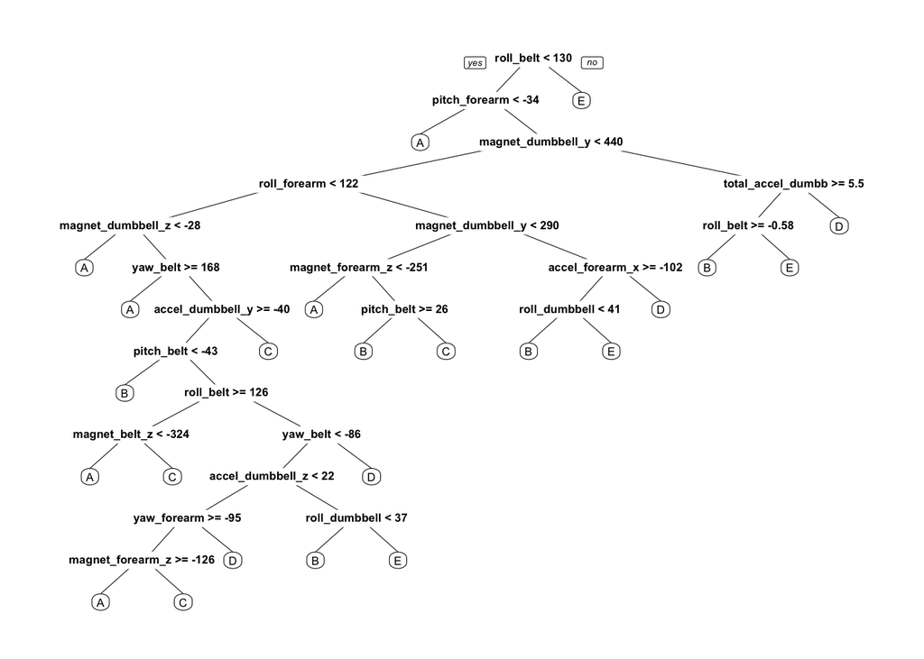

```r
treeModel <- rpart(classe~.,data=trainData,method="class")
prp(treeModel)
```